# Structure de données - Les Files

Une structure de données est une organisation logique des données permettant de simplifier ou d’accélérer leur traitement.

En informatique, une file (queue en anglais ) est une structure de données basée sur le prin- cipe «Premier entré,premier sorti», en anglais FIFO (First In, First Out), ce qui veut dire que les premiers éléments ajoutés à la file seront les premiers à être récupérés. Le fonctionnement ressemble à une file d’attente : les premières personnes à arriver sont les premières personnes à sortir de la file.

> Atention, bien que le principe «Premier entré,premier sorti» est équivalent, du point de vue formel, au principe «Dernier entré,dernier sortie» (Last In, Last Out), ce n'est pas le cas du point informatique. la gestion de la mémoire est diffférente.

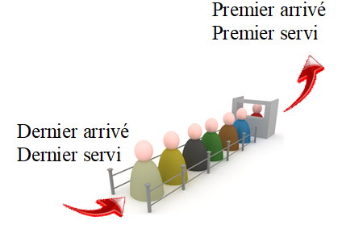

### Voici quelques exemples d’usage courant d’une file:

- En général, on utilise des files pour mémoriser temporairement des transactions qui doivent attendre pour être traitées
- Les serveurs d’impression, qui doivent traiter les requêtes dans l’ordre dans lequel elles arrivent, et les insèrent dans une file d’attente (ou une queue).
- Certains moteurs multitâches, dans un système d’exploitation, qui doivent accorder du temps-machine à chaque tâche, sans en privilégier aucune

### Pour implémenter une structure de file, on a besoin d’un nombre réduit d’opérations de bases :

- «enfiler» : ajoute un élément dans la file. Terme anglais correspondant : « enqueue »
- «défiler» : renvoie le prochain élément de la file, et le retire de la file. Terme anglais cor- respondant : « dequeue »
- «vide» : renvoie vrai si la file est vide, faux sinon
- «remplissage» : renvoie le nombre d’éléments dans la file.

La structure de file est un concept abstrait. Comment la réaliser dans la pratique? Voici plusieurs implémentations possibles. L’idée principale étant que les fonctions de bases pourront être utilisées indépendamment de l’implémentation choisie

# Implémentation - Méthode 1

Nous utiliserons une simple liste pour représenter la file. Là encore nous utiliserons `append(x)` et `pop(0)` pour réaliser les méthodes "enfiler" et "défiler"

Voici les fonctions de base :

```python
def file():
    """retourne une file vide"""
    return []
def vide(f):
    """Renvoie True si la file est vide et False sinon"""
    return f==[]
def enfiler(f,x):
    """#ajoute x à la file f"""
    return f.append(x)
def defiler(f):
    """#enlève et renvoie le premier élément de la file"""
    assert not vide(f), "file vide"
    return f.pop(0)
```

## Tester les instructions suivantes:

```python
f=file()
for i in range(5):
    enfiler(f,2*i)
print(f)
a=defiler(f)
print(a)
print(f)
print(vide(f))
```

# Exercice 1

Réaliser les fonctions `taille(p)` et `sommet(p)` qui retournent respectiveement la taille de la file et le somme de la file (c'est à dire le premier à sortir)

- Vous ne pouvez utiliser que les fonctions `file`, `vide`, `enfiler` et `defiler`.
- La file `p` doit être à sont état d'origine à la fin des processus.

```python
def taille(p):
    """revoie la taille d'une file p"""




def sommet(p):
    """renvoie le sommet d'une file p"""



print(taille(f))
print(f)
print(sommet(f))
print(f)
```

# Implémentation - Méthode 2

Nous allons créer une classe `File` pour implémenter la structure de file.

En vous inspirant de ce que l’on a vu pour la classe `Pile()`, réaliser cette implémenta- tion

```python
class File:
    def __init__(self):
        """Initialisation d’une file vide"""

    def vide(self):
        """teste si la file est vide"""

    def defiler(self):
        """Defile une file et renvoie le sommet"""

    def enfiler(self,x):
        """enfile l'element x dans la file """
```

Ecrire les instructions permettant de :

- créer une file
- la remplir avec les entiers 0,2,4,6,8
- la faire afficher
- "défiler" la file en faisant afficher l’élément récupéré

```python
#Code à écrire ici
```

# Exercice 2

Réaliser les méthodes `taille` et `sommet` qui retournent respectivement la taille de la file et le somme de la file (c'est à dire le premier à sortir)

- Vous ne pouvez utiliser que les méthodes de la classe `File`.
- La file doit être à sont état d'origine à la fin des processus.

```python
class File:
    def __init__(self):
        """Initialisation d’une file vide"""

    def vide(self):
        """teste si la file est vide"""

    def defiler(self):
        """Defile une file et renvoie le sommet"""

    def enfiler(self,x):
        """enfile l'element x dans la file """

    def taille(self):
        """retourne la taille d'une file"""

    def sommet(self):
        """retourne le sommet d'une file"""
```

# Exercice 3 : Croisement routier

Pour simuler un croisement routier, à sens unique, on utilise 3 files f1, f2 et f3 représentant respectivement les voitures arrivant sur des routes R1 et R2, et les voitures partant sur la route R3. La route R2 a un STOP. Les voitures de la file f2 ne peuvent avancer que s’il n’y a aucune voiture sur la route R1, donc dans la file f1.

[figure not shown]

On souhaite écrire un algorithme qui simule le départ des voitures sur la route R3, modélisée par la file f3.

- Dans la file f1 on représentera la présence d’une voiture par le nombre 1 et l’absence de voiture par 0;
- Dans la file f2 on représentera la présence d’une voiture par le nombre 2 et l’absence de voiture par 0;
- On n’utilisera que les méthodes `enfiler`, `defiler`, `sommet` et `vide`.
- On testera l’algorithme sur f 1 : tête <–[0, 1, 1, 0, 1]<– queue
- On testera l’algorithme sur f 2 : tête <–[0, 2, 2, 2, 0, 2, 0]<– queue
- Le résultat attendu : f3 tête <–[0, 1, 1, 2, 1, 2, 2, 0, 2, 0]<– queue

### Question 1

Que doit faire l’algorithme si les deux sommets des files sont à 0 ?

### Question 2

Que doit faire l’algorithme si le sommet de f1 est à 1 et celui de f2 à 2 ?

### Question 3

Que doit faire l’algorithme si le sommet de f1 est à 1 et celui de f2 à 0 ?

### Question 4

ue doit faire l’algorithme si le sommet de f1 est à 0 et celui de f2 à 2 ?

### Question 5

Que doit faire l’algorithme si l’une des deux files est vide ?

### Question 6

Écrire un code qui modélise ce carrefour, on utilisera une fonction `croisement(f1,f2)`qui prend en paramètres deux files f1 et f2 et qui retourne une file f3 contenant la file f3 des voitures sur la route R3. Réaliser le programme et tester le dans différents scénarios.

```python
def croisement(f1,f2):
    """Modelisation d'un croisement"""
```

# EXERCICES

### Exercice 4

On dispose d’une file, écrire une fonction qui renvoie la file inversée (l’élément de la tête sera situé à la queue et ainsi de suite ). On utilisera une pile et seulement les méthodes associées aux piles et aux files.

### Exercice 5 :

Même question mais pour une pile (on utilisera une ....).

### Exercice 6 :

On dispose d’une file contenant des entiers, écrire une fonction qui renvoie une file où on aura séparé les nombres pairs des impairs.

### Exercice 7 :

On dispose d’une pile contenant des entiers, écrire une fonction qui renvoie une pile où l’on aura séparés les nombres pairs des impairs.

### Exercice 8 :

On dispose d’une pile contenant des entiers, écrire une fonction ou une méthode qui renvoie une pile où l’on aura supprimé le premier élément entré.

### Exercice 9 :

On dispose d’une file contenant des entiers, écrire une fonction ou une méthode qui renvoie une file où l’on aura supprimé le dernier élément entré.

# Exercice 10 : Croisement routier, un prolongement possible

Complexifier la situation en imaginant des croisements successifs de trois ou quatre routes avec des STOP et des priorités à droite..